# HongKongAirbnb

Yonkee ZHENG

# Mining of HK Airbnb data

Data from http://insideairbnb.com/get-the-data

```r
library(dplyr)
```

```r
library(ggplot2)
library(tidyverse)
library(leaflet)
```

```r
listing = read.csv('HongKongAirbnb.csv')
head(listing)
```

```
##       id                                          name host_id host_name
## 1  17891                       Large Light Filled Loft   69063   Candace
## 2  72571                    SoHo off Hollywood Road 3A  304876     Brend
## 3 103760 Central Centre 5 min walk to/from Central MTR  304876     Brend
## 4 104626           Entire Flat - Next to Man Mo Temple  544166    Celine
## 5 132773             Fabulous 2 Bdrm Aprt Open kitchen  304876     Brend
## 6 163664                    Soho off Hollywood Road P4  304876     Brend
##   host_response_time host_response_rate host_acceptance_rate
## 1                                    NA                 1.00
## 2 within a few hours               1.00                 0.96
## 3 within a few hours               1.00                 0.96
## 4 a few days or more               0.13                 1.00
## 5 within a few hours               1.00                 0.96
## 6 within a few hours               1.00                 0.96
##   neighbourhood_cleansed latitude longitude       room_type accommodates price
```

[output cut: 20 more lines]

Change the data type of last_review to Date in order to visualize easier later.

```r
listing$last_review = as.Date.character(listing$last_review)
head(listing)
```

```
##       id                                          name host_id host_name
## 1  17891                       Large Light Filled Loft   69063   Candace
## 2  72571                    SoHo off Hollywood Road 3A  304876     Brend
## 3 103760 Central Centre 5 min walk to/from Central MTR  304876     Brend
## 4 104626           Entire Flat - Next to Man Mo Temple  544166    Celine
## 5 132773             Fabulous 2 Bdrm Aprt Open kitchen  304876     Brend
## 6 163664                    Soho off Hollywood Road P4  304876     Brend
##   host_response_time host_response_rate host_acceptance_rate
## 1                                    NA                 1.00
## 2 within a few hours               1.00                 0.96
## 3 within a few hours               1.00                 0.96
## 4 a few days or more               0.13                 1.00
## 5 within a few hours               1.00                 0.96
## 6 within a few hours               1.00                 0.96
##   neighbourhood_cleansed latitude longitude       room_type accommodates price
```

[output cut: 20 more lines]

Check whether price and minimum night are non-negative. And to get the minimum total money, I multiply price and minimum_nights.

```r
table(listing$price <= 0)
```

```
##
## FALSE  TRUE
##  4577     1
```

```r
table(listing$minimum_nights<=0)
```

```
##
## FALSE
##  4578
```

```r
listing$minimum_total_money = listing$price * listing$minimum_nights
```

Select the data where price is non-negative.

```r
listing1 = listing[!(listing$price<=0),]
head(listing1)
```

```
##       id                                          name host_id host_name
## 1  17891                       Large Light Filled Loft   69063   Candace
## 2  72571                    SoHo off Hollywood Road 3A  304876     Brend
## 3 103760 Central Centre 5 min walk to/from Central MTR  304876     Brend
## 4 104626           Entire Flat - Next to Man Mo Temple  544166    Celine
## 5 132773             Fabulous 2 Bdrm Aprt Open kitchen  304876     Brend
## 6 163664                    Soho off Hollywood Road P4  304876     Brend
##   host_response_time host_response_rate host_acceptance_rate
## 1                                    NA                 1.00
## 2 within a few hours               1.00                 0.96
## 3 within a few hours               1.00                 0.96
## 4 a few days or more               0.13                 1.00
## 5 within a few hours               1.00                 0.96
## 6 within a few hours               1.00                 0.96
##   neighbourhood_cleansed latitude longitude       room_type accommodates price
```

[output cut: 27 more lines]

```r
summary(listing1)
```

```
##        id               name              host_id           host_name
##  Min.   :   17891   Length:4577        Min.   :    69063   Length:4577
##  1st Qu.:19496317   Class :character   1st Qu.: 10575316   Class :character
##  Median :31866902   Mode  :character   Median : 59114014   Mode  :character
##  Mean   :29708528                      Mean   : 89550277
##  3rd Qu.:39432074                      3rd Qu.:132767139
##  Max.   :54329869                      Max.   :438418910
##
##  host_response_time host_response_rate host_acceptance_rate
##  Length:4577        Min.   :0.0000     Min.   :0.0000
##  Class :character   1st Qu.:0.9100     1st Qu.:0.2300
##  Mode  :character   Median :0.9600     Median :0.5100
##                     Mean   :0.8997     Mean   :0.5631
##                     3rd Qu.:1.0000     3rd Qu.:0.9500
##                     Max.   :1.0000     Max.   :1.0000
##                     NA's   :349        NA's   :513
##  neighbourhood_cleansed    latitude       longitude      room_type
##  Length:4577            Min.   :22.19   Min.   :113.9   Length:4577
##  Class :character       1st Qu.:22.28   1st Qu.:114.2   Class :character
##  Mode  :character       Median :22.29   Median :114.2   Mode  :character
##                         Mean   :22.30   Mean   :114.2
##                         3rd Qu.:22.31   3rd Qu.:114.2
##                         Max.   :22.53   Max.   :114.4
##
##   accommodates        price          minimum_nights    number_of_reviews
##  Min.   : 1.000   Min.   :     1.0   Min.   :   1.00   Min.   :  0.00
##  1st Qu.: 1.000   1st Qu.:   180.0   1st Qu.:   1.00   1st Qu.:  0.00
##  Median : 2.000   Median :   400.0   Median :  28.00   Median :  0.00
##  Mean   : 2.491   Mean   :   834.5   Mean   :  22.73   Mean   : 19.19
##  3rd Qu.: 2.000   3rd Qu.:   766.0   3rd Qu.:  29.00   3rd Qu.: 11.00
##  Max.   :16.000   Max.   :117631.0   Max.   :1125.00   Max.   :985.00
##
##   last_review         reviews_per_month availability_365 review_scores_value
##  Min.   :2012-02-06   Min.   : 0.0100   Min.   :  0.0    Min.   :1.000
##  1st Qu.:2019-07-13   1st Qu.: 0.0900   1st Qu.: 83.0    1st Qu.:4.360
##  Median :2021-02-16   Median : 0.2900   Median :298.0    Median :4.630
##  Mean   :2020-10-28   Mean   : 0.7288   Mean   :230.8    Mean   :4.479
##  3rd Qu.:2022-07-31   3rd Qu.: 0.9000   3rd Qu.:364.0    3rd Qu.:4.830
##  Max.   :2022-09-16   Max.   :11.6400   Max.   :365.0    Max.   :5.000
##  NA's   :2354         NA's   :2354                       NA's   :2391
##  calculated_host_listings_count minimum_total_money
##  Min.   :  1.0                  Min.   :      88
##  1st Qu.:  4.0                  1st Qu.:    1254
##  Median : 27.0                  Median :    5220
##  Mean   :121.9                  Mean   :   17578
##  3rd Qu.:257.0                  3rd Qu.:    9000
##  Max.   :384.0                  Max.   :12714120
##
```

The most important variable is price. Hence, I want to see the overall distribution of price.

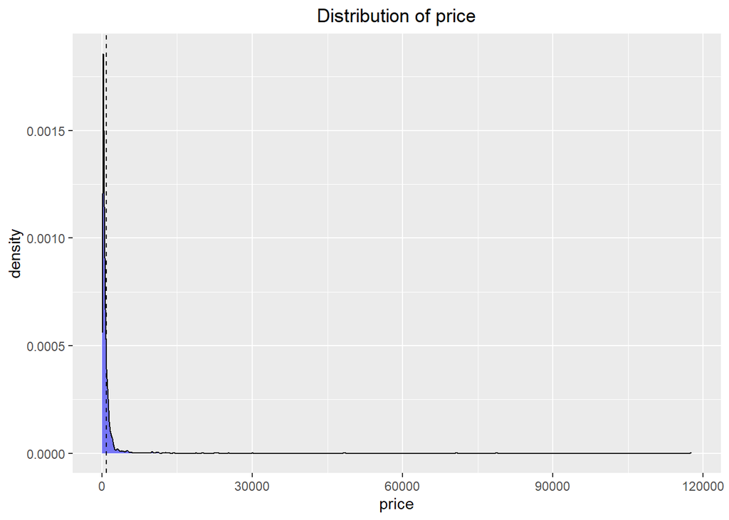

```r
ggplot(listing1, aes(price)) +
  geom_density(alpha = 0.5, fill = "blue") +
  ggtitle("Distribution of price") +
  theme(plot.title = element_text(hjust = 0.5)) +
  geom_vline(xintercept = mean(listing1$price), size = 0.5, linetype = 2)
```

Since the distribution is very skewed, it’s better to use log transformation to gain a better insight.

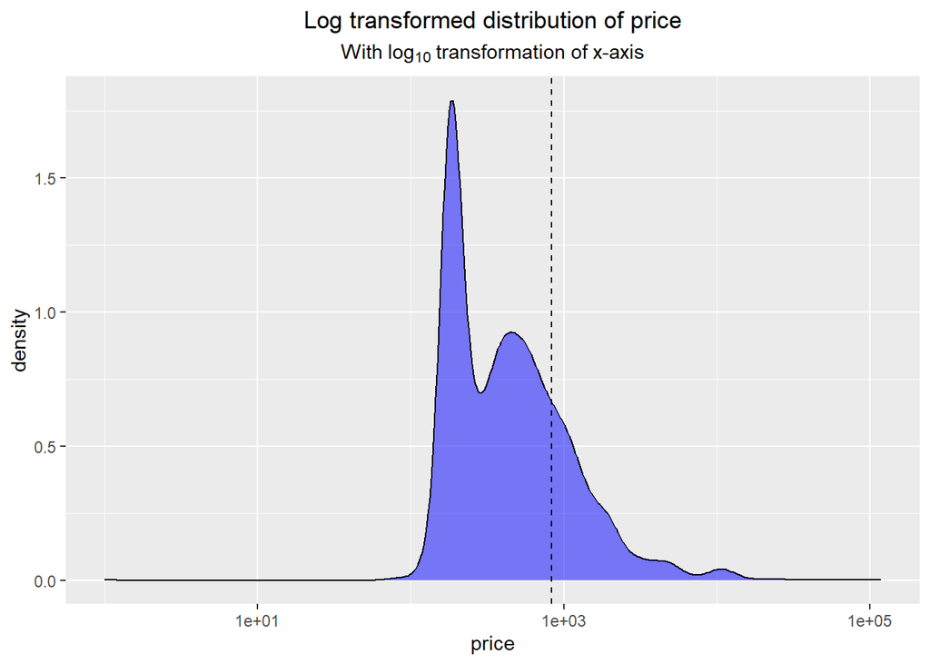

```r
ggplot(listing1, aes(price)) +
  geom_density(alpha = 0.5, fill = "blue") +
  ggtitle("Log transformed distribution of price",
          subtitle = expression("With" ~'log'[10] ~ "transformation of x-axis")) +
  theme(plot.title = element_text(hjust = 0.5),
        plot.subtitle = element_text(hjust = 0.5),
        axis.title = element_text()) +
  geom_vline(xintercept = mean(listing1$price), size = 0.5, linetype = 2) +
  scale_x_log10()
```

Average Price of each Neighbourhood

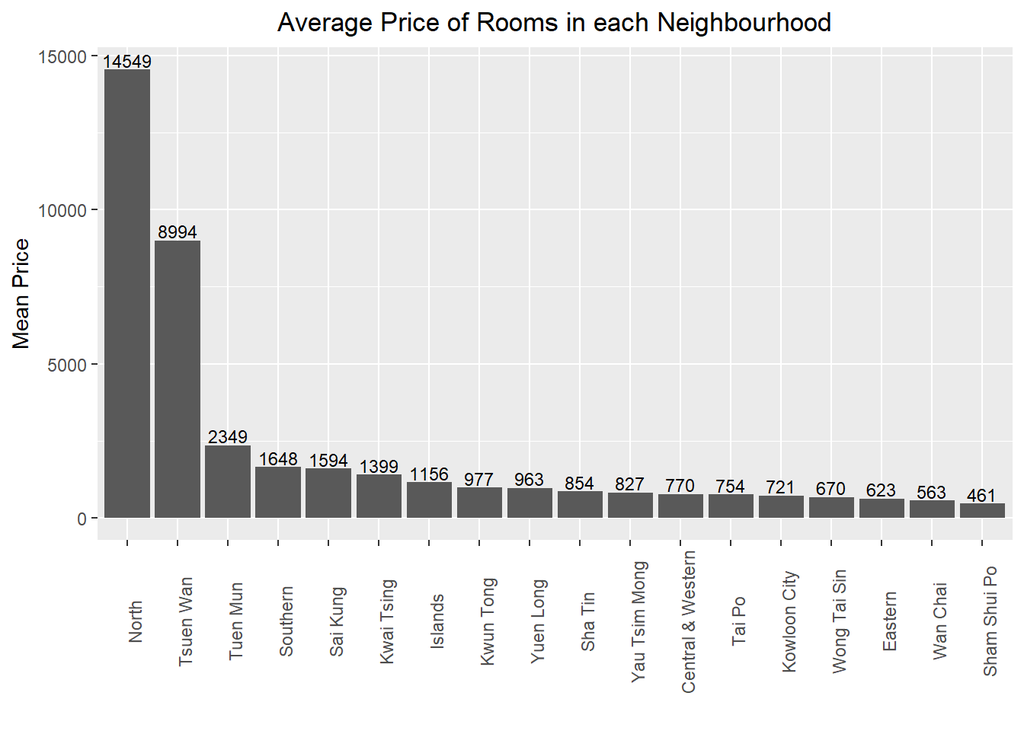

```r
nbh.price = listing1 %>% group_by(neighbourhood_cleansed) %>%
  summarise(mean_price = mean(price)) %>% arrange(desc(mean_price))
ggplot(nbh.price, aes(x = reorder(neighbourhood_cleansed, -mean_price), y = mean_price)) +
  geom_bar(stat="identity") +
  labs(title="Average Price of Rooms in each Neighbourhood") +
  theme(plot.title = element_text(hjust = 0.5), axis.text.x = element_text(angle = 90)) +
  xlab("") + ylab("Mean Price") +
  geom_text(aes(label = round(mean_price,0)),vjust=-0.2, size=3)
```

The log transformed distribution of each neighbourhood.

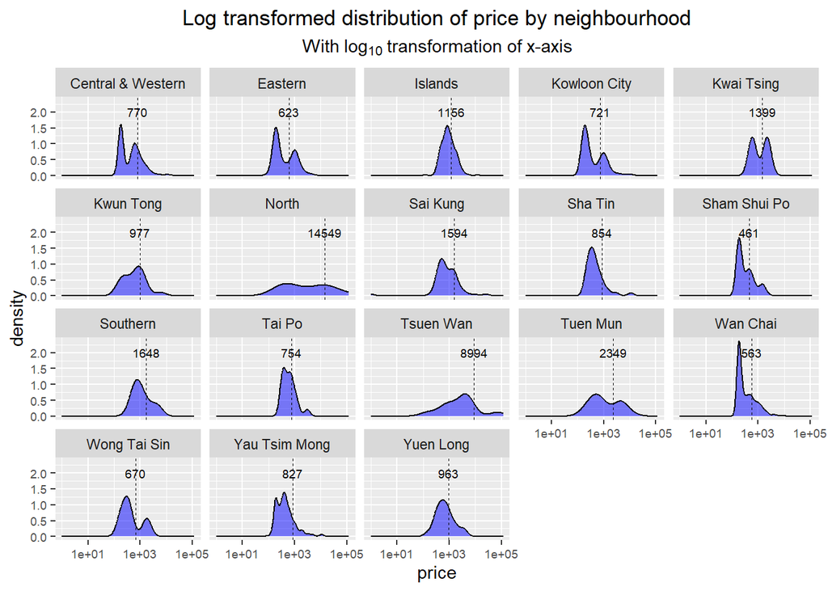

```r
ggplot(listing1, aes(price)) +
  geom_density(alpha = 0.5, fill = "blue") +
  ggtitle("Log transformed distribution of price by neighbourhood",
          subtitle = expression("With" ~'log'[10] ~ "transformation of x-axis")) +
  theme(plot.title = element_text(hjust = 0.5), plot.subtitle = element_text(hjust = 0.5),
        axis.text.y = element_text(size = 7), axis.text.x = element_text(size = 7)) +
  geom_vline(data = nbh.price, aes(xintercept = mean_price), size = 0.2, linetype = 2) +
  facet_wrap(~neighbourhood_cleansed) +
  scale_x_log10() +
  geom_text(data = nbh.price, y = 2, size = 2.5,
            aes(x = mean_price, label = round(mean_price,0)))
```

Then analyze the price of rooms by different room types.

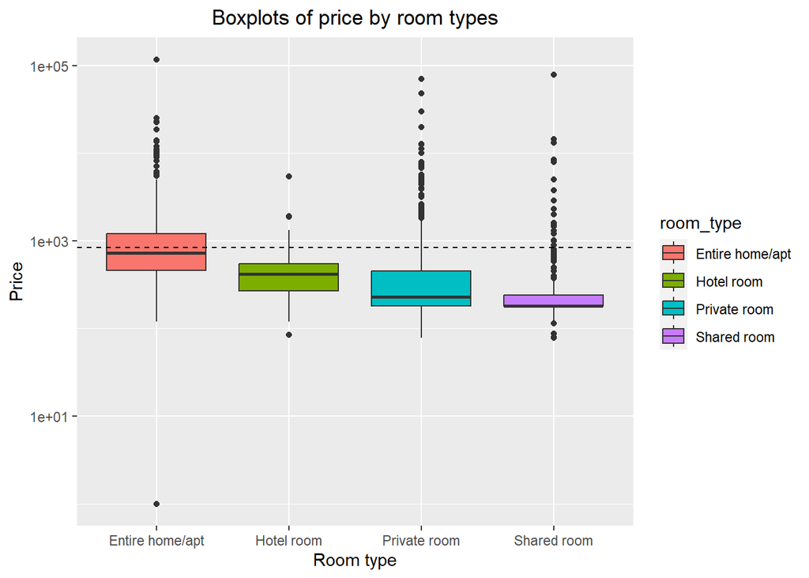

```r
ggplot(listing1, aes(x = room_type, y = price)) +
  geom_boxplot(aes(fill = room_type)) +
  scale_y_log10() +
  xlab("Room type") + ylab("Price") +
  ggtitle("Boxplots of price by room types") +
  theme(plot.title = element_text(hjust = 0.5)) +
  geom_hline(yintercept = mean(listing1$price), linetype = 2)
```

The entire home or apartment has the highest average price, while shared room has the lowest average price.

Also analyze the minimum total price of each room type.

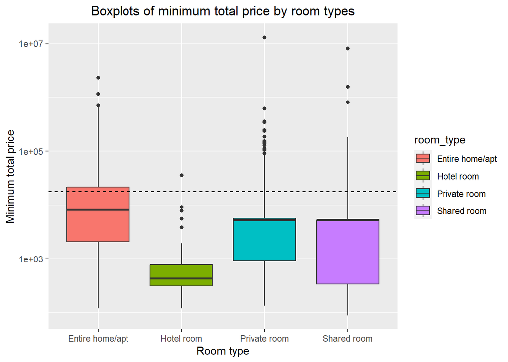

```r
ggplot(listing1, aes(x = room_type, y = minimum_total_money)) +
  geom_boxplot(aes(fill = room_type)) +
  scale_y_log10() +
  xlab("Room type") + ylab("Minimum total price") +
  ggtitle("Boxplots of minimum total price by room types") +
  theme(plot.title = element_text(hjust = 0.5)) +
  geom_hline(yintercept = mean(listing1$minimum_total_money), linetype = 2)
```

The entire home or apartment has the highest average minimum total price. Surprisingly, hotel room has the lowest average minimum total price.

Comparison of mean price of each neighbourhood and room types.

```r
nbh.rt.price <- listing1 %>% group_by(neighbourhood_cleansed, room_type) %>%
  summarise(mean_price = mean(price))
```

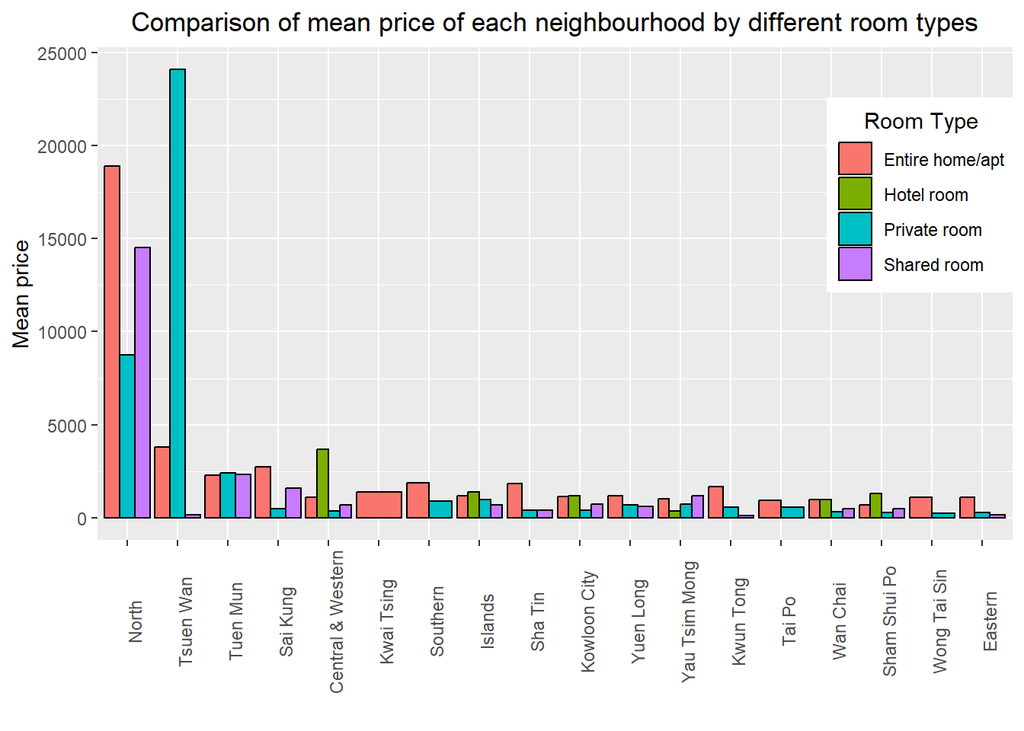

```r
ggplot(nbh.rt.price, aes(x = reorder(neighbourhood_cleansed, -mean_price),
                         y = mean_price, fill = room_type)) +
  geom_bar(stat="identity",colour="black",position=position_dodge()) +
  labs(title="Comparison of mean price of each neighbourhood by different room types") +
  theme(plot.title = element_text(hjust = 0.5),
        plot.subtitle = element_text(hjust = 0.5),
        axis.text.x = element_text(angle = 90),
        legend.position = c(0.9, 0.7), legend.title.align = 0.5) +
  xlab("") + ylab("Mean price") +
  scale_fill_discrete(name = 'Room Type')
```

Find the relationship between the price and availability in a year.

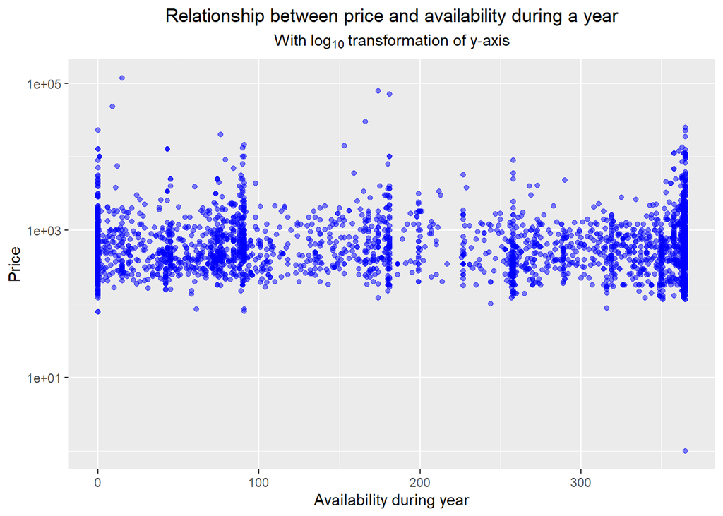

```r
ggplot(listing1, aes(availability_365, price)) +
  geom_point(alpha = 0.5, color = 'blue') +
  xlab("Availability during year") + ylab("Price") +
  ggtitle("Relationship between price and availability during a year",
          subtitle = expression("With" ~'log'[10] ~ "transformation of y-axis")) +
  theme(plot.title = element_text(hjust = 0.5),
        plot.subtitle = element_text(hjust = 0.5)) +
  scale_y_log10()
```

There is not a clear pattern in this figure and hence no relationship between price and availability during a year.

Find the relationship between minimum total money and number of reviews.

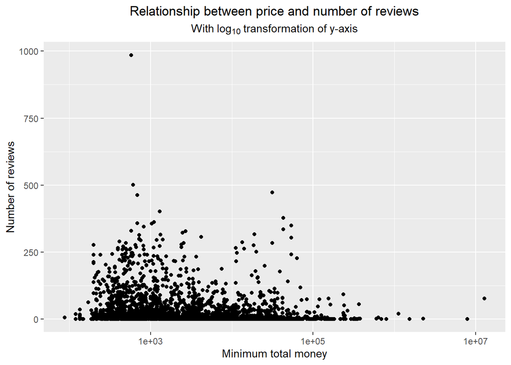

```r
ggplot(listing1, aes(minimum_total_money, number_of_reviews)) +
  geom_point() +
  xlab('Minimum total money') +  ylab("Number of reviews") +
  ggtitle("Relationship between price and number of reviews",
          subtitle = expression("With" ~'log'[10] ~ "transformation of y-axis")) +
  theme(plot.title = element_text(hjust = 0.5),
        plot.subtitle = element_text(hjust = 0.5)) +
  scale_x_log10()
```

Find the relationship between the price and host response time.

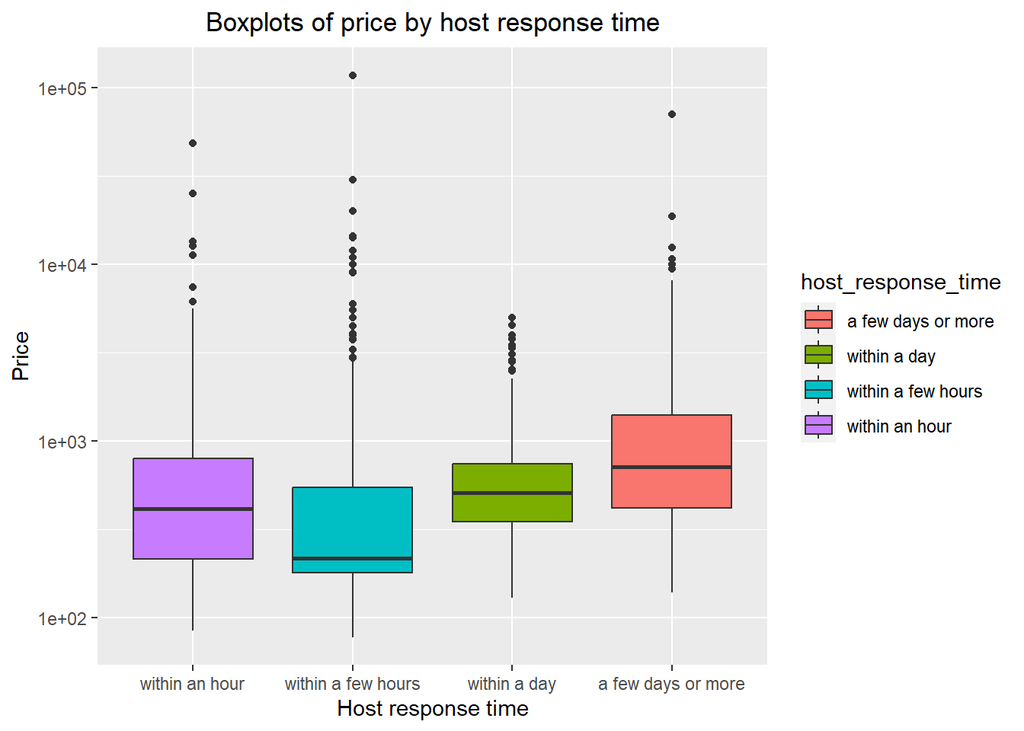

```r
listing2 = listing1 %>% drop_na(host_response_rate)
listing2$host_response_time_reorder = factor(listing2$host_response_time,
  levels = c('within an hour', 'within a few hours','within a day','a few days or more'))
ggplot(listing2, aes(x = host_response_time_reorder, y = price)) +
  geom_boxplot(aes(fill = host_response_time)) +
  scale_y_log10() +
  xlab("Host response time") + ylab("Price") +
  ggtitle("Boxplots of price by host response time") +
  theme(plot.title = element_text(hjust = 0.5))
```

Relationship between price and accommodates.

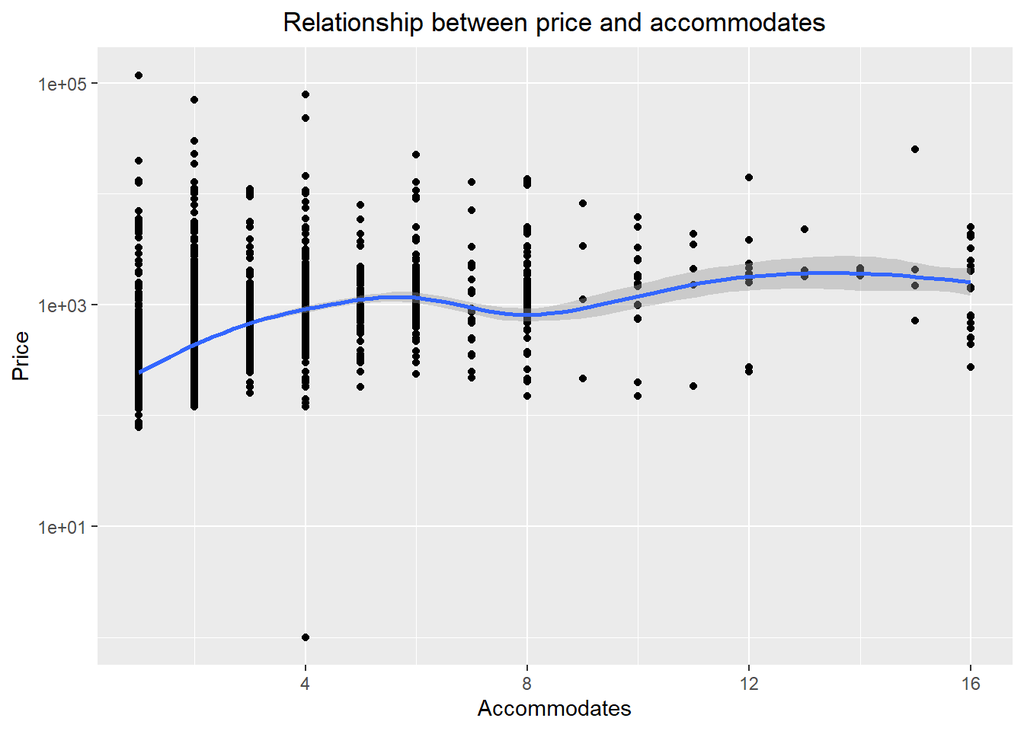

```r
ggplot(listing1, aes(x = accommodates, y = price)) +
  geom_point() +
  geom_smooth() +
  scale_y_log10() +
  xlab("Accommodates") + ylab("Price") +
  ggtitle("Relationship between price and accommodates") +
  theme(plot.title = element_text(hjust = 0.5))
```

Number of rooms by neighbourhood.

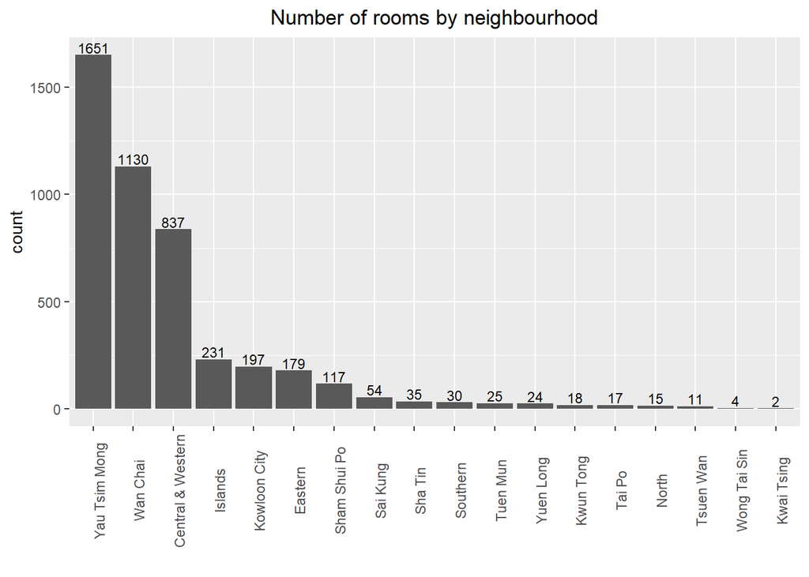

```r
nbh.count = listing1 %>% group_by(neighbourhood_cleansed) %>%
  summarise(count = n()) %>% arrange(desc(count))
ggplot(nbh.count, aes(x = reorder(neighbourhood_cleansed, -count), y = count)) +
  geom_bar(stat="identity") +
  labs(title="Number of rooms by neighbourhood") +
  theme(plot.title = element_text(hjust = 0.5), axis.text.x = element_text(angle = 90)) +
  xlab("") +
  geom_text(aes(label = count), vjust=-0.2, size=3)
```

Relationships between host response rate and review scores value.

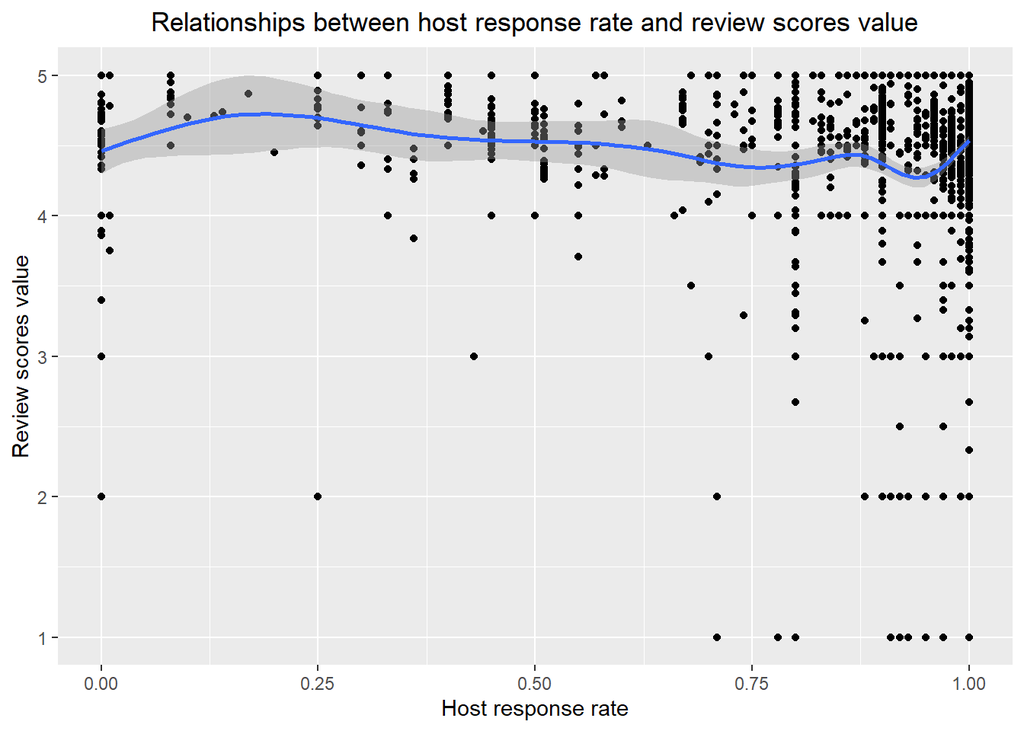

```r
ggplot(listing1,aes(host_response_rate, review_scores_value)) +
  geom_point() +
  geom_smooth() +
  ggtitle('Relationships between host response rate and review scores value') +
  xlab('Host response rate') + ylab('Review scores value') +
  theme(plot.title = element_text(hjust = 0.5))
```

Relationship between host acceptance rate and review scores value.

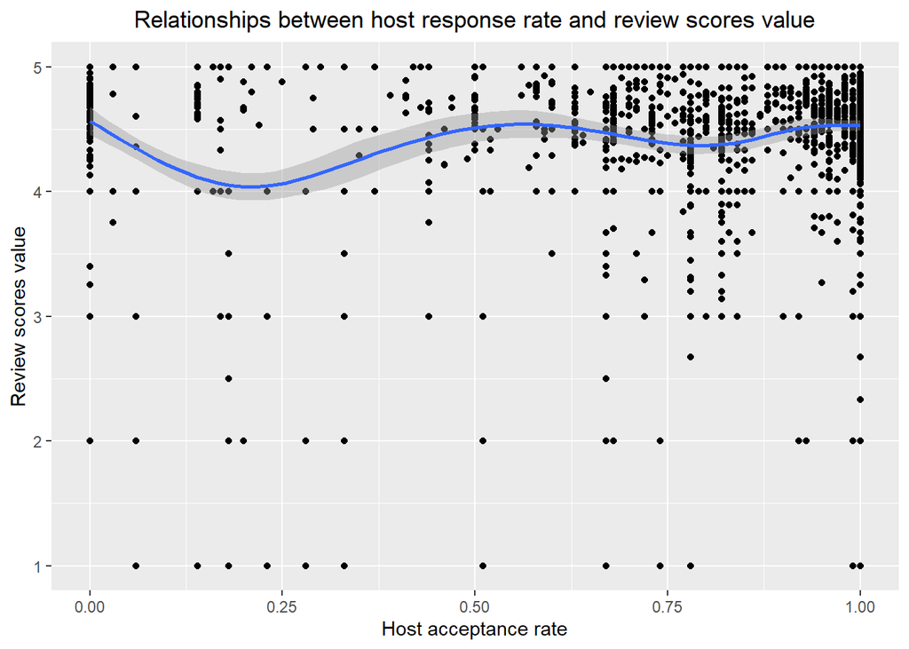

```r
ggplot(listing1,aes(host_acceptance_rate, review_scores_value)) +
  geom_point() +
  geom_smooth() +
  ggtitle('Relationships between host response rate and review scores value') +
  xlab('Host acceptance rate') + ylab('Review scores value') +
  theme(plot.title = element_text(hjust = 0.5))
```

Leaflet map

```r
pal = colorFactor(palette = "plasma",
                  listing1$neighbourhood_cleansed)
leaflet(data = listing1) %>% addProviderTiles(providers$CartoDB.DarkMatterNoLabels) %>%
  addCircleMarkers(~longitude, ~latitude, color = ~pal(neighbourhood_cleansed),
                   weight = 1, radius=1, fillOpacity = 0.1, opacity = 0.1,
                   label = paste("ID:", listing1$id)) %>%
     addLegend("bottomright", pal = pal, values = ~neighbourhood_cleansed,
     title = "Neighbourhood",
     opacity = 1)
```

[interactive chart not shown]